# OU process inference

```r
library(tidyverse)
library(rstan)
library(loo)
library(RColorBrewer)
options(mc.cores=4)
rstan_options(auto_write=TRUE)
source("helper.R")
set.seed(1)
```

In this notebook, we perform inference for the Orstein-Uhlenbeck (OU) process, which is described by the following SDE:

$$\begin{equation}
dX(t) = -\theta X(t) dt + \kappa dW(t).
\end{equation}$$

Throughout, we assume that $X(0)=10$ which is known, and $\theta$ and $\kappa$ are unknowns which we attempt to estimate. The observations are corrupted by Gaussian measurement noise of the form:

$$\begin{equation}
Y(t) \stackrel{i.i.d.}{\sim} \text{normal}(X(t), \sigma).
\end{equation}$$

We assume that $\sigma$ is also unknown.

We first simulate some data from the OU process with measurement noise using known parameters. Exact simulation of the OU process is possible, since the following probability distribution governs the density:

$$\begin{equation}
X(t+\delta t) | X(t) \sim \text{normal}(X(t)\exp(-\theta \delta_t),
\frac{\kappa^2}{2\theta}(1 - \exp(-2\theta \delta_t)))
\end{equation}$$

We first use this to simulate the state $X(t)$.

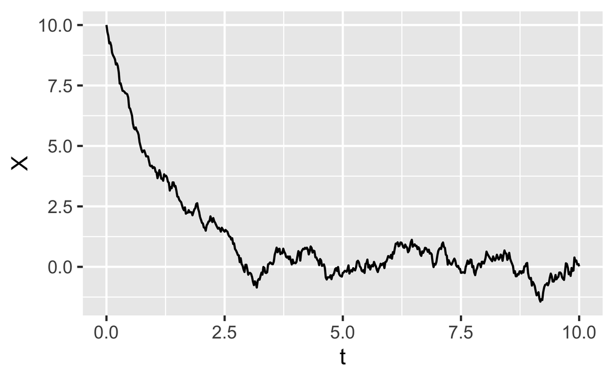

```r
simulate_ou <- function(X_0, T, N, theta, kappa) {
  delta_t <- T / N
  D <- kappa^2 / 2
  var <- D / theta * (1 - exp(-2 * delta_t))
  X <- vector(length = (N + 1))
  X[1] <- X_0
  for(i in 1:N) {
    X[i + 1] <- rnorm(1, X[i] * exp(-theta * delta_t), sqrt(var))
  }
  X
}

T <- 10
N <- 500
X_0 <- 10
theta <- 1
kappa <- 1
t <- seq(0, T, T/N)
X <- simulate_ou(X_0, T, N, theta, kappa)

# plot
df <- tibble(t, X)
df %>%
  ggplot(aes(x=t, y=X)) +
  geom_line()
```

We then add measurement noise and save the data for future use.

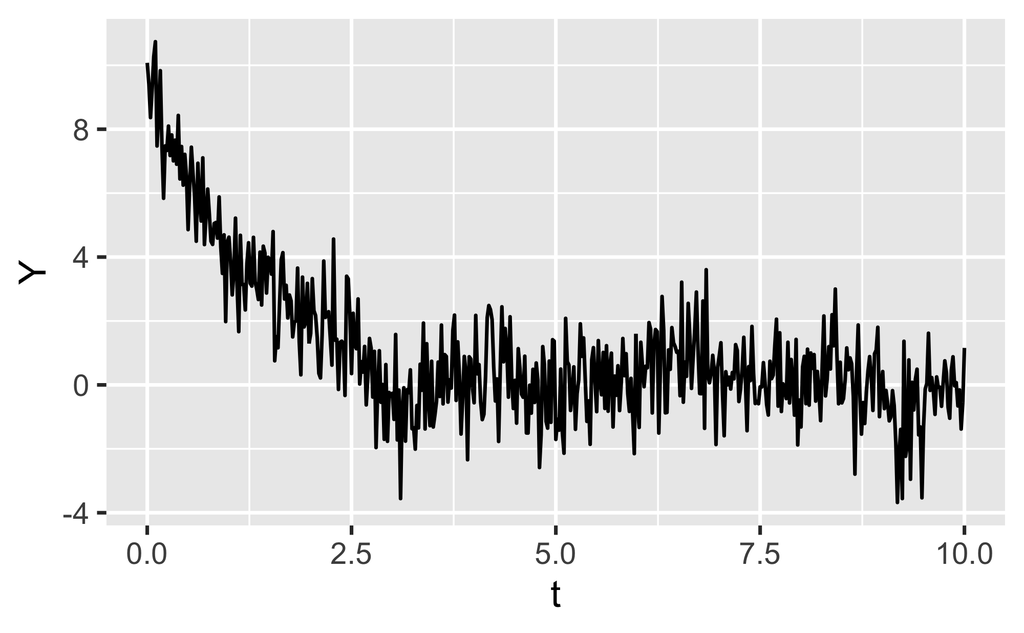

```r
sigma_n <- 1
Y <- rnorm(length(X), X, sigma_n)
df <- df %>%
  mutate(Y=Y)
df %>%
  ggplot(aes(x=t, y=Y)) +
  geom_line()
```

```r
# saveRDS(df, "../data/processed/ou_simulation.rds")

# remove zero time entry as causes issues for ODE integrator in Stan
df <- df %>%
  filter(t > 0)
```

# Exact inference

We now perform exact inference for the process. To do so, we use the result that if $X\sim \mathcal{N}(\mu, \Sigma)$ then $Y\sim \mathcal{N}(X, \sigma^2 I)$, then:

$$\begin{equation}
Y\sim \mathcal{N}(\mu, \Sigma + \sigma^2 I)
\end{equation}$$

It is straightforward to construct the matrix $\Sigma$. To do so, we consider:

$$\begin{align}
\text{cov}(X(t), X(t+\delta t)) &= \text{cov}(X(t),
X(t)\exp(-\theta\delta t) + \epsilon_t)\\
&= \text{cov}(X(t), X(t)\exp(-\theta\delta t))\\
&= \exp(-\theta\delta t)\text{var}(X(t))
&= \exp(-\theta\delta t) \times \kappa^2 / 2 (1 - \exp(-2\theta
t))\\
&= \kappa^2 / 2 (\exp(-\theta\delta t) - \exp(-\theta (2t +
\delta_t)))
\end{align}$$

where $\text{var}(X(t)) = \kappa^2 / 2 (1 - \exp(-2\theta t))$ is the variance of the OU process. More generally, the covariance between $X(t_1)$ and $X(t_2)$ is given by the result:

```r
model <- stan_model("stan/ou_exact.stan")
```

```
DIAGNOSTIC(S) FROM PARSER:
Info: Function abs(real) is deprecated in the Stan language.
         It will be removed in a future release.
         Use fabs(real) instead.
```

```r
stan_data <- list(
  nobs=nrow(df),
  t=df$t,
  Y=df$Y,
  X_0=X_0)
```